# Lab 10

Luke Todd

3/7/2022

#### Step 1: Set global options and load packages

```r
library(tidyverse)
library(here)
library(janitor)
library(readxl)
```

#### Step 2: Import water use data; clean data

The data for this lab are available from the [United States Geological Survey](https://water.usgs.gov/watuse/data/) for years 1950-2015. Table 1: “Sets” of data, for which each of the sets have ALL column tags in common. Data from USGS (1950-2015).

TABLE FOR PLOT 1: Organizes all the data that shows water use by fresh/saline sources for the industrial sector.

| year | fresh water | saline water | state |
| --- | --- | --- | --- |
| 1950 | inpt_wgw_fr + inpt_wsw_fr | NA | area |
| 1955 | inpt_wgw_fr + inpt_wsw_fr | inpt_wgw_sa + inpt_wsw_sa | area |
| 1960-1980 | oi_wgw_fr + oi_wsw_fr | oi_wgw_sa + oi_wsw_sa | area |
| 1985-1990 | in_wtofr | in_wtosa | scode |
| 1995 | in_w_fr_to | in_w_sa_to | state_code |
| 2000-2015 | in_w_fr_to | in_w_sa_to | statefips |

TABLE FOR PLOT 2: Lists all the data necessary to show total withdrawal vs. population for each state. Only pull from 2015 data.

| total withdrawals | state | population |
| --- | --- | --- |
| to_wtotl | state | tp_tot_pop |

```r
# Read data for 1950
d_1950 <- lapply(excel_sheets(here("data/us1950.xlsx")),
           function(x) read_excel(here("data/us1950.xlsx"), skip = 3, sheet = x)) %>%
           reduce(left_join, by = "Area") %>%
           clean_names() %>%
           select(-contains("note_industrial_and_thermoelectric_were_combined_in_1950")) %>%
           mutate(across(2:8, as.numeric))%>%
           replace(is.na(.), 0)

# Read data for 1955
d_1955 <- lapply(excel_sheets(here("data/us1955.xlsx")),
           function(x) read_excel(here("data/us1955.xlsx"), skip = 3, sheet = x)) %>%
           reduce(left_join, by = "Area") %>%
           clean_names() %>%
           select(-contains("note_industrial_and_thermoelectric_were_combined_in_1955"))%>%
           mutate(across(2:10, as.numeric)) %>%
           replace(is.na(.), 0)

# Read data for 1960
d_1960 <- lapply(excel_sheets(here("data/us1960.xlsx")),
           function(x) read_excel(here("data/us1960.xlsx"), skip = 3, sheet = x)) %>%
           reduce(left_join, by = "Area") %>%
           clean_names() %>%
           mutate(across(2:35, as.numeric)) %>%
           replace(is.na(.), 0)

# Read data for 1965
d_1965 <- lapply(excel_sheets(here("data/us1965.xlsx")),
           function(x) read_excel(here("data/us1965.xlsx"), skip = 3, sheet = x)) %>%
           reduce(left_join, by = "Area") %>%
           clean_names() %>%
           mutate(across(2:33, as.numeric)) %>%
           replace(is.na(.), 0)

# Read data for 1970
d_1970 <- lapply(excel_sheets(here("data/us1970.xlsx")),
           function(x) read_excel(here("data/us1970.xlsx"), skip = 3, sheet = x)) %>%
           reduce(left_join, by = "Area") %>%
           clean_names() %>%
           slice(1:52)  %>%
           mutate(across(2:34, as.numeric)) %>%
           replace(is.na(.), 0)

# Read data for 1975
d_1975 <- lapply(excel_sheets(here("data/us1975.xlsx")),
           function(x) read_excel(here("data/us1975.xlsx"), skip = 3, sheet = x)) %>%
           reduce(left_join, by = "Area") %>%
           clean_names() %>%
           mutate(across(2:34, as.numeric)) %>%
           replace(is.na(.), 0)

# Read data for 1980
d_1980 <- lapply(excel_sheets(here("data/us1980.xlsx")),
           function(x) read_excel(here("data/us1980.xlsx"), skip = 3, sheet = x)) %>%
           reduce(left_join, by = "Area") %>%
           clean_names() %>%
           mutate(across(2:34, as.numeric)) %>%
           replace(is.na(.), 0)

# Read data for 1985
d_1985 <- read_delim(here("data/us1985.txt")) %>%
           clean_names() %>%
           mutate(across(6:163, as.numeric)) %>%
           replace(is.na(.), 0)

# Read data for 1990
d_1990 <- read_xls(here("data/us1990.xls")) %>%
           clean_names() %>%
           slice(1:3225) %>%
           mutate(across(6:163, as.numeric)) %>%
           replace(is.na(.), 0)

# Read data for 1995
d_1995 <- read_xls(here("data/us1995.xls")) %>%
           clean_names() %>%
           mutate(across(c(1, 6:163), as.numeric)) %>%
           replace(is.na(.), 0)

# Read data for 2000
d_2000 <- read_xls(here("data/us2000.xls")) %>%
           clean_names() %>%
           mutate(across(5:70, as.numeric)) %>%
           replace(is.na(.), 0)

# Read data for 2005
d_2005 <- read_xls(here("data/us2005.xls")) %>%
           clean_names() %>%
           mutate(across(6:108, as.numeric)) %>%
           replace(is.na(.), 0)

# Read data for 2010
d_2010 <- read_xlsx(here("data/us2010.xlsx")) %>%
           clean_names() %>%
           mutate(across(6:117, as.numeric))%>%
           replace(is.na(.), 0)

# Read data for 2015
d_2015 <- read_xlsx(here("data/us2015.xlsx"), skip = 1) %>%
           clean_names() %>%
           mutate(across(6:141, as.numeric)) %>%
           replace(is.na(.), 0)
```

#### Step 3: Organize data by fresh/saline

```r
# DATA ORGANIZATION FOR PLOT 1:

# creates data frame for 1950 with new columns that add up to our desired values. used for plot 1
wu1_1950 <- d_1950 %>%
  mutate(State = area,
         Fresh_Water = inpt_wgw_fr + inpt_wsw_fr,
         Saline_Water = NA,
         Year = 1950) %>%
  select(State, Fresh_Water, Saline_Water, Year) %>%
  replace(is.na(.), 0) %>%
  group_by(State, Year) %>%
  summarize(across(1:2, sum)) %>%
  pivot_longer(3:4, names_to = "Water_Type", values_to = "Withdrawals")

# creates data frame for 1955 with new columns that add up to our desired values. used for plot 1
wu1_1955 <- d_1955 %>%
  mutate(State = area,
         Fresh_Water = inpt_wgw_fr + inpt_wsw_fr,
         Saline_Water = inpt_wgw_sa + inpt_wsw_sa,
         Year = 1955) %>%
  select(State, Fresh_Water, Saline_Water, Year) %>%
  replace(is.na(.), 0) %>%
  group_by(State, Year) %>%
  summarize(across(1:2, sum)) %>%
  pivot_longer(3:4, names_to = "Water_Type", values_to = "Withdrawals")

# creates data frame for 1960 with new columns that add up to our desired values. used for plot 1
wu1_1960 <- d_1960 %>%
  mutate(State = area,
         Fresh_Water = oi_wgw_fr + oi_wsw_fr,
         Saline_Water = oi_wgw_sa + oi_wsw_sa,
         Year = 1960) %>%
  select(State, Fresh_Water, Saline_Water, Year) %>%
  replace(is.na(.), 0) %>%
  group_by(State, Year) %>%
  summarize(across(1:2, sum)) %>%
  pivot_longer(3:4, names_to = "Water_Type", values_to = "Withdrawals")

# creates data frame for 1965 with new columns that add up to our desired values. used for plot 1
wu1_1965 <- d_1965 %>%
  mutate(State = area,
         Fresh_Water = oi_wgw_fr + oi_wsw_fr,
         Saline_Water = oi_wgw_sa + oi_wsw_sa,
         Year = 1965) %>%
  select(State, Fresh_Water, Saline_Water, Year) %>%
  replace(is.na(.), 0) %>%
  group_by(State, Year) %>%
  summarize(across(1:2, sum)) %>%
  pivot_longer(3:4, names_to = "Water_Type", values_to = "Withdrawals")

# creates data frame for 1970 with new columns that add up to our desired values. used for plot 1
wu1_1970 <- d_1970 %>%
  mutate(State = area,
         Fresh_Water = oi_wgw_fr + oi_wsw_fr,
         Saline_Water = oi_wgw_sa + oi_wsw_sa,
         Year = 1970) %>%
  select(State, Fresh_Water, Saline_Water, Year) %>%
  replace(is.na(.), 0) %>%
  group_by(State, Year) %>%
  summarize(across(1:2, sum)) %>%
  pivot_longer(3:4, names_to = "Water_Type", values_to = "Withdrawals")

# creates data frame for 1975 with new columns that add up to our desired values. used for plot 1
wu1_1975 <- d_1975 %>%
  mutate(State = area,
         Fresh_Water = oi_wgw_fr + oi_wsw_fr,
         Saline_Water = oi_wgw_sa + oi_wsw_sa,
         Year = 1975) %>%
  select(State, Fresh_Water, Saline_Water, Year) %>%
  replace(is.na(.), 0) %>%
  group_by(State, Year) %>%
  summarize(across(1:2, sum)) %>%
  pivot_longer(3:4, names_to = "Water_Type", values_to = "Withdrawals")

# creates data frame for 1980 with new columns that add up to our desired values. used for plot 1
wu1_1980 <- d_1980 %>%
  mutate(State = area,
         Fresh_Water = oi_wgw_fr + oi_wsw_fr,
         Saline_Water = oi_wgw_sa + oi_wsw_sa,
         Year = 1980) %>%
  select(State, Fresh_Water, Saline_Water, Year) %>%
  replace(is.na(.), 0) %>%
  group_by(State, Year) %>%
  summarize(across(1:2, sum)) %>%
  pivot_longer(3:4, names_to = "Water_Type", values_to = "Withdrawals")

# creates data frame for 1985 with new columns that add up to our desired values. used for plot 1
wu1_1985 <- d_1985 %>%
  mutate(State = scode,
         Fresh_Water = in_wtofr,
         Saline_Water = in_wtosa,
         Year = 1985) %>%
  select(State, Fresh_Water, Saline_Water, Year) %>%
  replace(is.na(.), 0) %>%
  group_by(State, Year) %>%
  summarize(across(1:2, sum)) %>%
  pivot_longer(3:4, names_to = "Water_Type", values_to = "Withdrawals")

# creates data frame for 1990 with new columns that add up to our desired values. used for plot 1
wu1_1990 <- d_1990 %>%
  mutate(State = scode,
         Fresh_Water = in_wtofr,
         Saline_Water = in_wtosa,
         Year = 1990) %>%
  select(State, Fresh_Water, Saline_Water, Year) %>%
  replace(is.na(.), 0) %>%
  group_by(State, Year) %>%
  summarize(across(1:2, sum)) %>%
  pivot_longer(3:4, names_to = "Water_Type", values_to = "Withdrawals")

# creates data frame for 1995 with new columns that add up to our desired values. used for plot 1
wu1_1995 <- d_1995 %>%
  mutate(State = state_code,
         Fresh_Water = in_w_fr_to,
         Saline_Water = in_w_sa_to,
         Year = 1995) %>%
  select(State, Fresh_Water, Saline_Water, Year) %>%
  replace(is.na(.), 0) %>%
  group_by(State, Year) %>%
  summarize(across(1:2, sum)) %>%
  pivot_longer(3:4, names_to = "Water_Type", values_to = "Withdrawals")

# creates data frame for 2000 with new columns that add up to our desired values. used for plot 1
wu1_2000 <- d_2000 %>%
  mutate(State = statefips,
         Fresh_Water = in_w_fr_to,
         Saline_Water = in_w_sa_to,
         Year = 2000) %>%
  select(State, Fresh_Water, Saline_Water, Year) %>%
  replace(is.na(.), 0) %>%
  group_by(State, Year) %>%
  summarize(across(1:2, sum)) %>%
  pivot_longer(3:4, names_to = "Water_Type", values_to = "Withdrawals")

# creates data frame for 2005 with new columns that add up to our desired values. used for plot 1
wu1_2005 <- d_2005 %>%
  mutate(State = statefips,
         Fresh_Water = in_w_fr_to,
         Saline_Water = in_w_sa_to,
         Year = 2005) %>%
  select(State, Fresh_Water, Saline_Water, Year) %>%
  replace(is.na(.), 0) %>%
  group_by(State, Year) %>%
  summarize(across(1:2, sum)) %>%
  pivot_longer(3:4, names_to = "Water_Type", values_to = "Withdrawals")

# creates data frame for 2010 with new columns that add up to our desired values. used for plot 1
wu1_2010 <- d_2010 %>%
  mutate(State = statefips,
         Fresh_Water = in_w_fr_to,
         Saline_Water = in_w_sa_to,
         Year = 2010) %>%
  select(State, Fresh_Water, Saline_Water, Year) %>%
  replace(is.na(.), 0) %>%
  group_by(State, Year) %>%
  summarize(across(1:2, sum)) %>%
  pivot_longer(3:4, names_to = "Water_Type", values_to = "Withdrawals")

# creates data frame for 2015 with new columns that add up to our desired values. used for plot 1
wu1_2015 <- d_2015 %>%
  mutate(State = statefips,
         Fresh_Water = in_w_fr_to,
         Saline_Water = in_w_sa_to,
         Year = 2015) %>%
  select(State, Fresh_Water, Saline_Water, Year) %>%
  replace(is.na(.), 0) %>%
  group_by(State, Year) %>%
  summarize(across(1:2, sum)) %>%
  pivot_longer(3:4, names_to = "Water_Type", values_to = "Withdrawals")


# DATA ORGANIZATION FOR PLOT 2

# selects for total withdrawals, population, and state, which are all the columns I will need. descending population order for graphing
wu2_2015 <- d_2015 %>%
  mutate(State = state,
         Total_Withdrawals = to_wtotl,
         Population = tp_tot_pop) %>%
  select(State, Total_Withdrawals, Population) %>%
  replace(is.na(.), 0) %>%
  group_by(State) %>%
  summarize(across(1:2, sum)) %>%
  arrange(., desc(Population))
```

#### Step 4: Organize and combine data for plotting

```r
# DATA PREP FOR PLOT 1:

# combines all the wu1_ objects and removes the 3 non-states
wu1_all <- rbind(wu1_1950, wu1_1955, wu1_1960, wu1_1965, wu1_1970, wu1_1975, wu1_1980, wu1_1985, wu1_1990, wu1_1995, wu1_2000, wu1_2005, wu1_2010, wu1_2015) %>%
          filter(!State %in% c("72", "11", "78"))

# sums all for the withdrawals for each year
wu1_all_total <- wu1_all %>%
                group_by(Year) %>%
                summarize(across(3, sum))

# sums all withdrawals for fresh/saline for each year
wu1_all_type <- wu1_all %>%
                group_by(Water_Type, Year) %>%
                summarize(across(2, sum))



# DATA PREP FOR PLOT 2:

# just created a new dataframe with only State and Population. was running into issues indexing with $
wu2_population <- wu2_2015 %>%
  select(State, Population) %>%
  arrange(., desc(Population))
```

#### Step 5: Setup plot 1 for timeseries of water type withdrawals in industrial sector

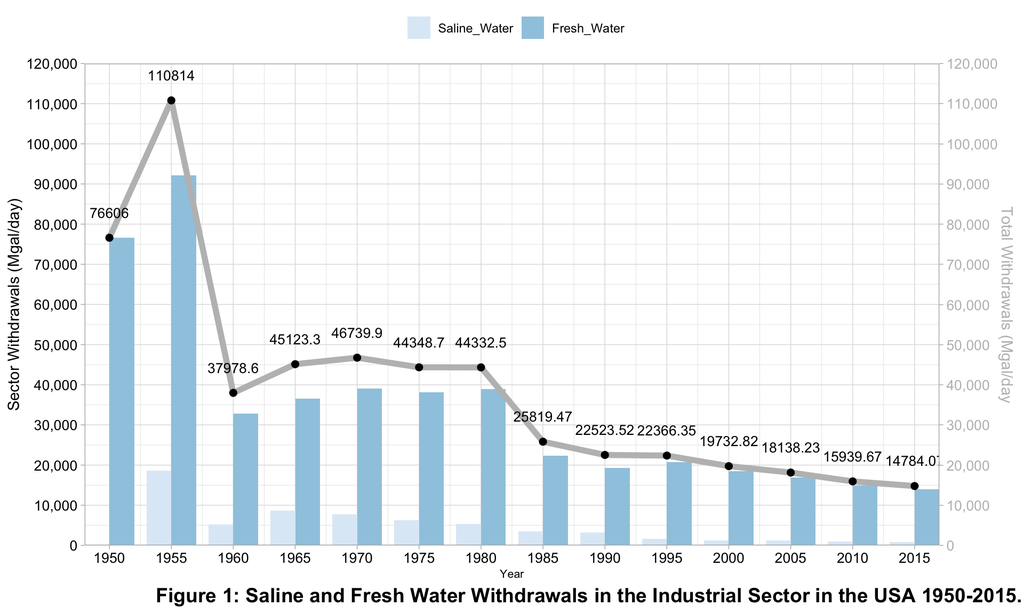

```r
# this plot is a time series that shows water withdrawals over time in the US. each year is split into the fresh and saline water withdrawals
# the barplot is overlayed with a line graph that shows the total water withdrawal for industrial (fresh + saline)
# the overlaying line graph helps show how the total withdrawals is often very reliant on the fresh water withdrawals
# the line graph also has points for each year, showing the data for total withdrawals for each year

ggplot() + geom_col(data = wu1_all_type,
                     aes(x = Year,
                         y = Withdrawals,
                         fill = reorder(Water_Type, Withdrawals)),
                     position = position_dodge(width = 4),
                     width = 4) +
            guides(fill=guide_legend(title="")) +
            scale_fill_brewer() +      # new function scale_fill_brewer()
            geom_line(data = wu1_all_total,
                      aes(x = Year,
                          y = Withdrawals),
                          size = 2,
                          color = "grey",
                      show.legend = FALSE) +
            scale_x_continuous(breaks = scales::pretty_breaks(n = 14),
                               expand = c(0, 0)) +
            scale_y_continuous(breaks = scales::pretty_breaks(n = 10),
                               labels = scales::comma,
                               limits = c(0, 120000),
                               sec.axis = sec_axis(trans = ~.*1,
                                        breaks = scales::pretty_breaks(n = 10),
                                        labels = scales::comma,
                                        name = "Total Withdrawals (Mgal/day"),
                               expand = c(0, 0)) +
            geom_text(data = wu1_all_total,
                      aes(label = Withdrawals, x = Year, y = Withdrawals),
                      vjust = -2,
                      color="black",
                      position = position_dodge(1),
                      size=3.5) +     # new function geom_text()
            geom_point(data = wu1_all_total,
                       aes(x = Year,
                           y = Withdrawals),
                           size = 2,
                           color = "black",
                       show.legend = FALSE) +
            labs(x = "Year",
                 y = "Sector Withdrawals (Mgal/day)",
                 caption = "Figure 1: Saline and Fresh Water Withdrawals in the Industrial Sector in the USA 1950-2015. Data from USGS (2015). Created by LUKE TODD.",
                 fill = "") +
            ggplot2::theme_light() +     # new function theme_light()
            theme(legend.position = "top",
                  legend.title = element_text(size = 10, color = "black"),
                  axis.title.x = element_text(color = "black", size = 8),
                  axis.text = element_text(color = "black", size = 10),
                  axis.text.y.right = element_text(color = "grey"),
                  axis.title.y.right = element_text(color = "grey"),
                  plot.caption = element_text(hjust = -0.15, size = 14, face = "bold"))
```

From the above plot, we can see that as time has passed, both the saline and the fresh water withdrawals related to the industrial sector has dropped.

#### Step 6: Setup plot 2: Withdrawals and population for each state

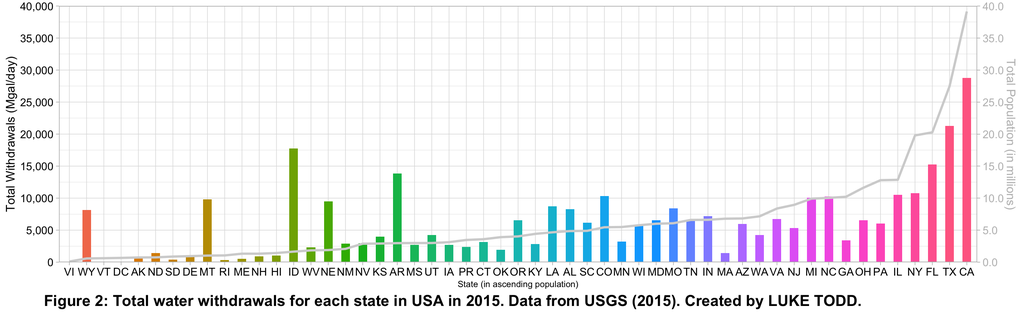

```r
# this plot shows total water withdrawal for each state. the states are arranged in ascending order.
# on top of the bar plot is a line graph that shows the total population for each state.
# the goal of the plot is to show a trend between population and state total water withdrawal

ggplot() + geom_col(data = wu2_2015,
                     aes(x = reorder(State, Population),
                         y = Total_Withdrawals,
                         fill = reorder(State, Population)),
                     width = 0.5) +
            guides(fill=guide_legend(title="")) +
            geom_line(data = wu2_population,
                      aes(x = reorder(State, Population),
                          y = Population, group = 1),
                          size = 1,
                          color = "light grey",
                      show.legend = FALSE) +
            ggplot2::theme_light() +

           # decided that a legend was not needed for this plot
            theme(legend.position = "None",
                  legend.title = element_text(size = 10, color = "black"),
                  axis.title.x = element_text(color = "black", size = 8),
                  axis.text = element_text(color = "black", size = 10),
                  axis.text.y.right = element_text(color = "grey"),
                  axis.title.y.right = element_text(color = "grey"),
                  plot.caption = element_text(hjust = -0.15, size = 14, face = "bold")) +
            labs(x = "State (in ascending population)",
                 y = "Total Withdrawals (Mgal/day)",
                 caption = "Figure 2: Total water withdrawals for each state in USA in 2015. Data from USGS (2015). Created by LUKE TODD.",
                 fill = "") +
              scale_y_continuous(breaks = scales::pretty_breaks(n = 10),
                               labels = scales::comma,
                               limits = c(0, 40000),
                               sec.axis = sec_axis(trans = ~./1000,
                                        breaks = scales::pretty_breaks(n = 10),
                                        labels = scales::comma,
                                        name = "Total Population (in millions)"),
                               expand = c(0, 0))
```

The above plot shows that on average, as population increases in a state, the total water withdrawals also increases. Some of the interesting outliers are states like Idaho, Montana, and Wyoming. I would assume that their water withdrawals stem mostly from agriculture or industry, since their populations are low relative to their water use.